# 1. Import and warehouse data:

# Importing Library

```python
import pandas as pd
import numpy as np
import matplotlib.pyplot as plt
%matplotlib inline
import seaborn as sns
import warnings
warnings.filterwarnings("ignore")
```

# Importing dataframe directly using pandas as a single csv file

```python
df = pd.read_csv('TelcomCustomer-Churn.csv')
df.head()
```

|  | customerID | gender | SeniorCitizen | Partner | Dependents | tenure | PhoneService | MultipleLines | InternetService | OnlineSecurity | ... | DeviceProtection | TechSupport | StreamingTV | StreamingMovies | Contract | PaperlessBilling | PaymentMethod | MonthlyCharges | TotalCharges | Churn |
| --- | --- | --- | --- | --- | --- | --- | --- | --- | --- | --- | --- | --- | --- | --- | --- | --- | --- | --- | --- | --- | --- |
| 0 | 7590-VHVEG | Female | 0 | Yes | No | 1 | No | No phone service | DSL | No | ... | No | No | No | No | Month-to-month | Yes | Electronic check | 29.85 | 29.85 | No |
| 1 | 5575-GNVDE | Male | 0 | No | No | 34 | Yes | No | DSL | Yes | ... | Yes | No | No | No | One year | No | Mailed check | 56.95 | 1889.5 | No |
| 2 | 3668-QPYBK | Male | 0 | No | No | 2 | Yes | No | DSL | Yes | ... | No | No | No | No | Month-to-month | Yes | Mailed check | 53.85 | 108.15 | Yes |
| 3 | 7795-CFOCW | Male | 0 | No | No | 45 | No | No phone service | DSL | Yes | ... | Yes | Yes | No | No | One year | No | Bank transfer (automatic) | 42.30 | 1840.75 | No |
| 4 | 9237-HQITU | Female | 0 | No | No | 2 | Yes | No | Fiber optic | No | ... | No | No | No | No | Month-to-month | Yes | Electronic check | 70.70 | 151.65 | Yes |

5 rows × 21 columns

```python
# Exploring the shape of the dataset
df.shape
print(f'''Telecom customer churn predictor dataset has {df.shape[0]} rows and {df.shape[1]} attributes.''')
```

```
Telecom customer churn predictor dataset has 7043 rows and 21 attributes.
```

```python
# getting info about data types of each attributes.
df.info()
```

```
<class 'pandas.core.frame.DataFrame'>
RangeIndex: 7043 entries, 0 to 7042
Data columns (total 21 columns):
 #   Column            Non-Null Count  Dtype
---  ------            --------------  -----
 0   customerID        7043 non-null   object
 1   gender            7043 non-null   object
 2   SeniorCitizen     7043 non-null   int64
 3   Partner           7043 non-null   object
 4   Dependents        7043 non-null   object
 5   tenure            7043 non-null   int64
 6   PhoneService      7043 non-null   object
 7   MultipleLines     7043 non-null   object
 8   InternetService   7043 non-null   object
 9   OnlineSecurity    7043 non-null   object
 10  OnlineBackup      7043 non-null   object
 11  DeviceProtection  7043 non-null   object
 12  TechSupport       7043 non-null   object
 13  StreamingTV       7043 non-null   object
 14  StreamingMovies   7043 non-null   object
 15  Contract          7043 non-null   object
 16  PaperlessBilling  7043 non-null   object
 17  PaymentMethod     7043 non-null   object
 18  MonthlyCharges    7043 non-null   float64
 19  TotalCharges      7043 non-null   object
 20  Churn             7043 non-null   object
dtypes: float64(1), int64(2), object(18)
memory usage: 1.1+ MB
```

# Importing the datasets via MYSQL database

```python
import mysql.connector as sql
```

```python
# importing the first dataset
db_connection =sql.connect(host='localhost',database='churn',user='root',password='1234')
db_cursor = db_connection.cursor()
db_cursor.execute('SELECT * FROM telcomcustomer_churn_1')
table_rows = db_cursor.fetchall()
df1 = pd.DataFrame(table_rows)
df1.head()
```

|  | 0 | 1 | 2 | 3 | 4 | 5 | 6 | 7 | 8 | 9 |
| --- | --- | --- | --- | --- | --- | --- | --- | --- | --- | --- |
| 0 | 7590-VHVEG | Female | 0 | Yes | No | 1 | No | No phone service | DSL | No |
| 1 | 5575-GNVDE | Male | 0 | No | No | 34 | Yes | No | DSL | Yes |
| 2 | 3668-QPYBK | Male | 0 | No | No | 2 | Yes | No | DSL | Yes |
| 3 | 7795-CFOCW | Male | 0 | No | No | 45 | No | No phone service | DSL | Yes |
| 4 | 9237-HQITU | Female | 0 | No | No | 2 | Yes | No | Fiber optic | No |

```python
# adding column names
col1 = ['customerID','gender','SeniorCitizen','Partner','Dependents','tenure','PhoneService','MultipleLines','InternetService','OnlineSecurity']
df1.columns=col1
df1.head()
```

|  | customerID | gender | SeniorCitizen | Partner | Dependents | tenure | PhoneService | MultipleLines | InternetService | OnlineSecurity |
| --- | --- | --- | --- | --- | --- | --- | --- | --- | --- | --- |
| 0 | 7590-VHVEG | Female | 0 | Yes | No | 1 | No | No phone service | DSL | No |
| 1 | 5575-GNVDE | Male | 0 | No | No | 34 | Yes | No | DSL | Yes |
| 2 | 3668-QPYBK | Male | 0 | No | No | 2 | Yes | No | DSL | Yes |
| 3 | 7795-CFOCW | Male | 0 | No | No | 45 | No | No phone service | DSL | Yes |
| 4 | 9237-HQITU | Female | 0 | No | No | 2 | Yes | No | Fiber optic | No |

```python
#exploring the shape of the dataset_1
df1.shape
print(f'''Telecom customer churn predictor_1 dataset has {df1.shape[0]} rows and {df1.shape[1]} attributes.''')
```

```
Telecom customer churn predictor_1 dataset has 7043 rows and 10 attributes.
```

```python
db_connection =sql.connect(host='localhost',database='churn',user='root',password='1234')
db_cursor = db_connection.cursor()
db_cursor.execute('SELECT * FROM telcomcustomer_churn_2')
table_rows = db_cursor.fetchall()
df2 = pd.DataFrame(table_rows)
col2 = ['OnlineBackup','DeviceProtection','TechSupport','StreamingTV','StreamingMovies','Contract','PaperlessBilling','PaymentMethod','MonthlyCharges','TotalCharges','Churn']
df2.columns = col2
df2.head()
```

|  | OnlineBackup | DeviceProtection | TechSupport | StreamingTV | StreamingMovies | Contract | PaperlessBilling | PaymentMethod | MonthlyCharges | TotalCharges | Churn |
| --- | --- | --- | --- | --- | --- | --- | --- | --- | --- | --- | --- |
| 0 | Yes | No | No | No | No | Month-to-month | Yes | Electronic check | 29.85 | 29.85 | No |
| 1 | No | Yes | No | No | No | One year | No | Mailed check | 56.95 | 1889.50 | No |
| 2 | Yes | No | No | No | No | Month-to-month | Yes | Mailed check | 53.85 | 108.15 | Yes |
| 3 | No | Yes | Yes | No | No | One year | No | Bank transfer (automatic) | 42.30 | 1840.75 | No |
| 4 | No | No | No | No | No | Month-to-month | Yes | Electronic check | 70.70 | 151.65 | Yes |

```python
#exploring the shape of the dataset_2
df2.shape
print(f'''Telecom customer churn predictor_2 dataset has {df2.shape[0]} rows and {df2.shape[1]} attributes.''')
```

```
Telecom customer churn predictor_2 dataset has 7032 rows and 11 attributes.
```

# Merge all datasets onto one and explore final shape and size.

```python
df_new = df1.join(df2)
df_new.head()
```

|  | customerID | gender | SeniorCitizen | Partner | Dependents | tenure | PhoneService | MultipleLines | InternetService | OnlineSecurity | ... | DeviceProtection | TechSupport | StreamingTV | StreamingMovies | Contract | PaperlessBilling | PaymentMethod | MonthlyCharges | TotalCharges | Churn |
| --- | --- | --- | --- | --- | --- | --- | --- | --- | --- | --- | --- | --- | --- | --- | --- | --- | --- | --- | --- | --- | --- |
| 0 | 7590-VHVEG | Female | 0 | Yes | No | 1 | No | No phone service | DSL | No | ... | No | No | No | No | Month-to-month | Yes | Electronic check | 29.85 | 29.85 | No |
| 1 | 5575-GNVDE | Male | 0 | No | No | 34 | Yes | No | DSL | Yes | ... | Yes | No | No | No | One year | No | Mailed check | 56.95 | 1889.50 | No |
| 2 | 3668-QPYBK | Male | 0 | No | No | 2 | Yes | No | DSL | Yes | ... | No | No | No | No | Month-to-month | Yes | Mailed check | 53.85 | 108.15 | Yes |
| 3 | 7795-CFOCW | Male | 0 | No | No | 45 | No | No phone service | DSL | Yes | ... | Yes | Yes | No | No | One year | No | Bank transfer (automatic) | 42.30 | 1840.75 | No |
| 4 | 9237-HQITU | Female | 0 | No | No | 2 | Yes | No | Fiber optic | No | ... | No | No | No | No | Month-to-month | Yes | Electronic check | 70.70 | 151.65 | Yes |

5 rows × 21 columns

```python
#exploring the final shape of the dataset
df_new.shape
print(f'''Telecom customer churn predictor_2 dataset has {df.shape[0]} rows and {df.shape[1]} attributes.''')
```

```
Telecom customer churn predictor_2 dataset has 7043 rows and 21 attributes.
```

```python
# Datatypes of the attributes
df_new.info()
```

```
<class 'pandas.core.frame.DataFrame'>
RangeIndex: 7043 entries, 0 to 7042
Data columns (total 21 columns):
 #   Column            Non-Null Count  Dtype
---  ------            --------------  -----
 0   customerID        7043 non-null   object
 1   gender            7043 non-null   object
 2   SeniorCitizen     7043 non-null   int64
 3   Partner           7043 non-null   object
 4   Dependents        7043 non-null   object
 5   tenure            7043 non-null   int64
 6   PhoneService      7043 non-null   object
 7   MultipleLines     7043 non-null   object
 8   InternetService   7043 non-null   object
 9   OnlineSecurity    7043 non-null   object
 10  OnlineBackup      7032 non-null   object
 11  DeviceProtection  7032 non-null   object
 12  TechSupport       7032 non-null   object
 13  StreamingTV       7032 non-null   object
 14  StreamingMovies   7032 non-null   object
 15  Contract          7032 non-null   object
 16  PaperlessBilling  7032 non-null   object
 17  PaymentMethod     7032 non-null   object
 18  MonthlyCharges    7032 non-null   float64
 19  TotalCharges      7032 non-null   float64
 20  Churn             7032 non-null   object
dtypes: float64(2), int64(2), object(17)
memory usage: 1.1+ MB
```

# 2. Data cleansing

# Missing value treatment

```python
# let us check how many missing values are there in each attributes.
df.isnull().sum()
```

```
customerID          0
gender              0
SeniorCitizen       0
Partner             0
Dependents          0
tenure              0
PhoneService        0
MultipleLines       0
InternetService     0
OnlineSecurity      0
OnlineBackup        0
DeviceProtection    0
TechSupport         0
StreamingTV         0
StreamingMovies     0
Contract            0
PaperlessBilling    0
PaymentMethod       0
MonthlyCharges      0
TotalCharges        0
Churn               0
dtype: int64
```

Found there are no missing value in the dataset.

```python
df.info()
```

```
<class 'pandas.core.frame.DataFrame'>
RangeIndex: 7043 entries, 0 to 7042
Data columns (total 21 columns):
 #   Column            Non-Null Count  Dtype
---  ------            --------------  -----
 0   customerID        7043 non-null   object
 1   gender            7043 non-null   object
 2   SeniorCitizen     7043 non-null   int64
 3   Partner           7043 non-null   object
 4   Dependents        7043 non-null   object
 5   tenure            7043 non-null   int64
 6   PhoneService      7043 non-null   object
 7   MultipleLines     7043 non-null   object
 8   InternetService   7043 non-null   object
 9   OnlineSecurity    7043 non-null   object
 10  OnlineBackup      7043 non-null   object
 11  DeviceProtection  7043 non-null   object
 12  TechSupport       7043 non-null   object
 13  StreamingTV       7043 non-null   object
 14  StreamingMovies   7043 non-null   object
 15  Contract          7043 non-null   object
 16  PaperlessBilling  7043 non-null   object
 17  PaymentMethod     7043 non-null   object
 18  MonthlyCharges    7043 non-null   float64
 19  TotalCharges      7043 non-null   object
 20  Churn             7043 non-null   object
dtypes: float64(1), int64(2), object(18)
memory usage: 1.1+ MB
```

```python
# converting 'TotalCharges' datatype to numeric
df['TotalCharges'] = pd.to_numeric(df['TotalCharges'],errors='coerce')
```

```python
df.isnull().sum()
```

```
customerID           0
gender               0
SeniorCitizen        0
Partner              0
Dependents           0
tenure               0
PhoneService         0
MultipleLines        0
InternetService      0
OnlineSecurity       0
OnlineBackup         0
DeviceProtection     0
TechSupport          0
StreamingTV          0
StreamingMovies      0
Contract             0
PaperlessBilling     0
PaymentMethod        0
MonthlyCharges       0
TotalCharges        11
Churn                0
dtype: int64
```

```python
# impute the missing values in  'TotalCharges' by median of the same column
df['TotalCharges'] = df.TotalCharges.fillna(df['TotalCharges'].median())
```

```python
# checking once again for the missing value
df.isnull().sum()
```

```
customerID          0
gender              0
SeniorCitizen       0
Partner             0
Dependents          0
tenure              0
PhoneService        0
MultipleLines       0
InternetService     0
OnlineSecurity      0
OnlineBackup        0
DeviceProtection    0
TechSupport         0
StreamingTV         0
StreamingMovies     0
Contract            0
PaperlessBilling    0
PaymentMethod       0
MonthlyCharges      0
TotalCharges        0
Churn               0
dtype: int64
```

Found no null or missing value after imputing

# Convert categorical attributes to continuous using relevant functional knowledge

```python
df.head()
```

|  | customerID | gender | SeniorCitizen | Partner | Dependents | tenure | PhoneService | MultipleLines | InternetService | OnlineSecurity | ... | DeviceProtection | TechSupport | StreamingTV | StreamingMovies | Contract | PaperlessBilling | PaymentMethod | MonthlyCharges | TotalCharges | Churn |
| --- | --- | --- | --- | --- | --- | --- | --- | --- | --- | --- | --- | --- | --- | --- | --- | --- | --- | --- | --- | --- | --- |
| 0 | 7590-VHVEG | Female | 0 | Yes | No | 1 | No | No phone service | DSL | No | ... | No | No | No | No | Month-to-month | Yes | Electronic check | 29.85 | 29.85 | No |
| 1 | 5575-GNVDE | Male | 0 | No | No | 34 | Yes | No | DSL | Yes | ... | Yes | No | No | No | One year | No | Mailed check | 56.95 | 1889.50 | No |
| 2 | 3668-QPYBK | Male | 0 | No | No | 2 | Yes | No | DSL | Yes | ... | No | No | No | No | Month-to-month | Yes | Mailed check | 53.85 | 108.15 | Yes |
| 3 | 7795-CFOCW | Male | 0 | No | No | 45 | No | No phone service | DSL | Yes | ... | Yes | Yes | No | No | One year | No | Bank transfer (automatic) | 42.30 | 1840.75 | No |
| 4 | 9237-HQITU | Female | 0 | No | No | 2 | Yes | No | Fiber optic | No | ... | No | No | No | No | Month-to-month | Yes | Electronic check | 70.70 | 151.65 | Yes |

5 rows × 21 columns

```python
# checking uniqueness of each attribute.
for i in df.columns:
    print(f'''unique values in '{i}' are: {df[i].unique()}''')
    print('\n')
```

```
unique values in 'customerID' are: ['7590-VHVEG' '5575-GNVDE' '3668-QPYBK' ... '4801-JZAZL' '8361-LTMKD'
 '3186-AJIEK']


unique values in 'gender' are: ['Female' 'Male']


unique values in 'SeniorCitizen' are: [0 1]


unique values in 'Partner' are: ['Yes' 'No']


unique values in 'Dependents' are: ['No' 'Yes']


unique values in 'tenure' are: [ 1 34  2 45  8 22 10 28 62 13 16 58 49 25 69 52 71 21 12 30 47 72 17 27
  5 46 11 70 63 43 15 60 18 66  9  3 31 50 64 56  7 42 35 48 29 65 38 68
 32 55 37 36 41  6  4 33 67 23 57 61 14 20 53 40 59 24 44 19 54 51 26  0
 39]


unique values in 'PhoneService' are: ['No' 'Yes']


unique values in 'MultipleLines' are: ['No phone service' 'No' 'Yes']


unique values in 'InternetService' are: ['DSL' 'Fiber optic' 'No']


unique values in 'OnlineSecurity' are: ['No' 'Yes' 'No internet service']


unique values in 'OnlineBackup' are: ['Yes' 'No' 'No internet service']


unique values in 'DeviceProtection' are: ['No' 'Yes' 'No internet service']


```

[output cut: 11 more lines]

```

unique values in 'PaperlessBilling' are: ['Yes' 'No']


unique values in 'PaymentMethod' are: ['Electronic check' 'Mailed check' 'Bank transfer (automatic)'
 'Credit card (automatic)']


unique values in 'MonthlyCharges' are: [29.85 56.95 53.85 ... 63.1  44.2  78.7 ]


unique values in 'TotalCharges' are: [  29.85 1889.5   108.15 ...  346.45  306.6  6844.5 ]


unique values in 'Churn' are: ['No' 'Yes']
```

From the above observation it is found that there are some replacement should be incarporated to the categorical variables of the column.

```python
#dropping the customerID column
df.drop('customerID',axis=1,inplace=True)
```

```python
#will incarporate changes in categorical variable with cosmetic change
df['gender'].replace(['Female','Male'],[0,1],inplace=True)
df['Partner'].replace(['Yes','No'],[1,0],inplace=True)
df['Dependents'].replace(['No','Yes'],[0,1],inplace=True)
df['PhoneService'].replace(['No','Yes'],[0,1],inplace=True)
df['MultipleLines'].replace(['No phone service', 'No', 'Yes'],[0,0,1],inplace=True)
df['InternetService'].replace(['DSL', 'Fiber optic','No'],[1,2,0],inplace=True)
df['OnlineSecurity'].replace(['No','Yes','No internet service'],[0,1,0],inplace=True)
df['OnlineBackup'].replace(['Yes','No','No internet service'],[1,0,0],inplace=True)
df['DeviceProtection'].replace(['No','Yes','No internet service'],[0,1,0],inplace=True)
df['TechSupport'].replace(['No','Yes','No internet service'],[0,1,0],inplace=True)
df['StreamingTV'].replace(['No','Yes','No internet service'],[0,1,0],inplace=True)
df['StreamingMovies'].replace(['No','Yes','No internet service'],[0,1,0],inplace=True)
df['Contract'].replace(['Month-to-month','One year','Two year'],[0,1,2],inplace=True)
df['PaperlessBilling'].replace(['Yes','No'],[1,0],inplace=True)
df['PaymentMethod'].replace(['Electronic check', 'Mailed check', 'Bank transfer (automatic)',
 'Credit card (automatic)'],[0,1,2,3],inplace=True)
df['Churn'].replace(['No','Yes'],[0,1],inplace=True)
df.info()
```

```
<class 'pandas.core.frame.DataFrame'>
RangeIndex: 7043 entries, 0 to 7042
Data columns (total 20 columns):
 #   Column            Non-Null Count  Dtype
---  ------            --------------  -----
 0   gender            7043 non-null   int64
 1   SeniorCitizen     7043 non-null   int64
 2   Partner           7043 non-null   int64
 3   Dependents        7043 non-null   int64
 4   tenure            7043 non-null   int64
 5   PhoneService      7043 non-null   int64
 6   MultipleLines     7043 non-null   int64
 7   InternetService   7043 non-null   int64
 8   OnlineSecurity    7043 non-null   int64
 9   OnlineBackup      7043 non-null   int64
 10  DeviceProtection  7043 non-null   int64
 11  TechSupport       7043 non-null   int64
 12  StreamingTV       7043 non-null   int64
 13  StreamingMovies   7043 non-null   int64
 14  Contract          7043 non-null   int64
 15  PaperlessBilling  7043 non-null   int64
 16  PaymentMethod     7043 non-null   int64
 17  MonthlyCharges    7043 non-null   float64
 18  TotalCharges      7043 non-null   float64
 19  Churn             7043 non-null   int64
dtypes: float64(2), int64(18)
memory usage: 1.1 MB
```

# 3. Data analysis & visualisation

# Perform detailed statistical analysis on the data

```python
# There are only 3 continious variable in the present dataset
df[['tenure','MonthlyCharges','TotalCharges']].describe().T
```

|  | count | mean | std | min | 25% | 50% | 75% | max |
| --- | --- | --- | --- | --- | --- | --- | --- | --- |
| tenure | 7043.0 | 32.371149 | 24.559481 | 0.00 | 9.000 | 29.000 | 55.00 | 72.00 |
| MonthlyCharges | 7043.0 | 64.761692 | 30.090047 | 18.25 | 35.500 | 70.350 | 89.85 | 118.75 |
| TotalCharges | 7043.0 | 2281.916928 | 2265.270398 | 18.80 | 402.225 | 1397.475 | 3786.60 | 8684.80 |

# Univariate, bivariate and multivariate analysis

# Univariate analysis

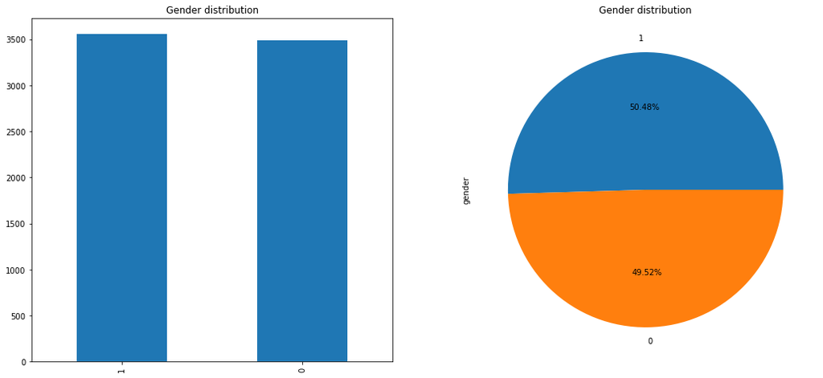

```python
# will check the distribution of the categorical variable
plt.figure(figsize=(18,8))
plt.subplot(1,2,1)
plt.title('Gender distribution')
df.gender.value_counts().plot.bar();

plt.subplot(1,2,2)
plt.title('Gender distribution')
df.gender.value_counts().plot.pie(autopct='%1.2f%%');
```

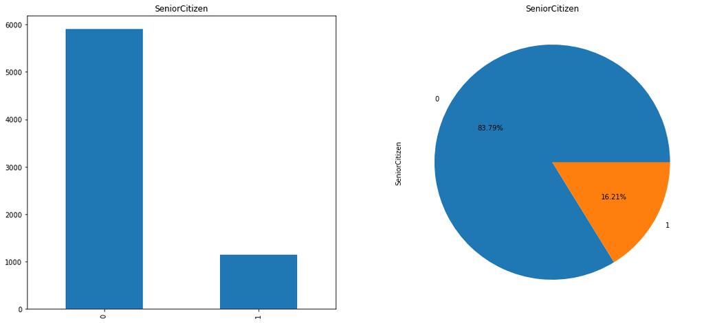

```python
plt.figure(figsize=(18,8))
plt.subplot(1,2,1)
plt.title('SeniorCitizen')
df.SeniorCitizen.value_counts().plot.bar();

plt.subplot(1,2,2)
plt.title('SeniorCitizen')
df.SeniorCitizen.value_counts().plot.pie(autopct='%1.2f%%');
```

the distribution 0(not a senior citizen) is 83.79% and 1(senior citizen) distribution is 16.21%.

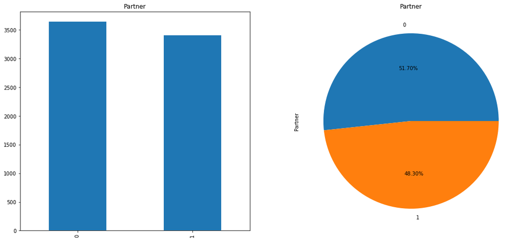

```python
plt.figure(figsize=(18,8))
plt.subplot(1,2,1)
plt.title('Partner')
df.Partner.value_counts().plot.bar();

plt.subplot(1,2,2)
plt.title('Partner')
df.Partner.value_counts().plot.pie(autopct='%1.2f%%');
```

the distribution are 0(not having a partner) is 51.7% and 1(having partner) distribution is 48.3%.

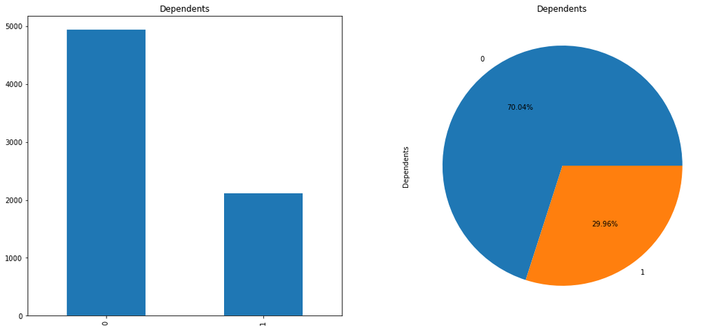

```python
plt.figure(figsize=(18,8))
plt.subplot(1,2,1)
plt.title('Dependents')
df.Dependents.value_counts().plot.bar();

plt.subplot(1,2,2)
plt.title('Dependents')
df.Dependents.value_counts().plot.pie(autopct='%1.2f%%');
```

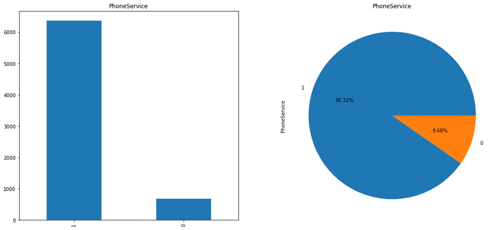

```python
plt.figure(figsize=(18,8))
plt.subplot(1,2,1)
plt.title('PhoneService')
df.PhoneService.value_counts().plot.bar();

plt.subplot(1,2,2)
plt.title('PhoneService')
df.PhoneService.value_counts().plot.pie(autopct='%1.2f%%');
```

the distribution 0(no PhoneService) is 9.68% and 1(PhoneService) distribution is 90.32%.

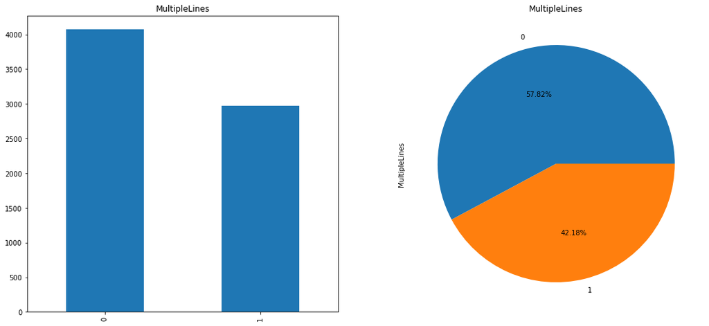

```python
plt.figure(figsize=(18,8))
plt.subplot(1,2,1)
plt.title('MultipleLines')
df.MultipleLines.value_counts().plot.bar();

plt.subplot(1,2,2)
plt.title('MultipleLines')
df.MultipleLines.value_counts().plot.pie(autopct='%1.2f%%');
```

the distribution 0 (no PhoneService/multiple lines) is 57.82% and 1 (Multiple lines) distribution is 42.18%.

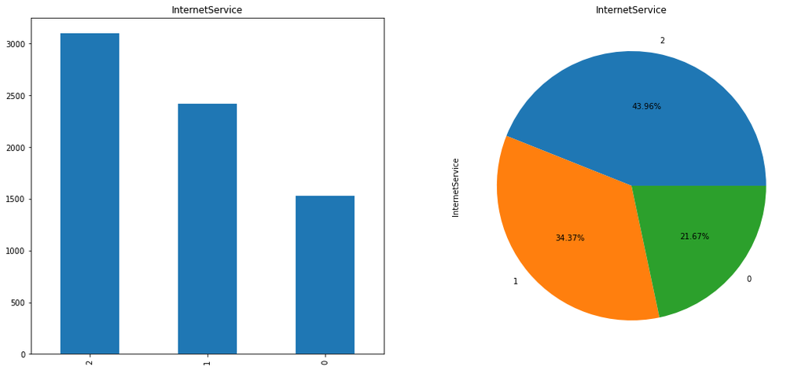

```python
plt.figure(figsize=(18,8))
plt.subplot(1,2,1)
plt.title('InternetService')
df.InternetService.value_counts().plot.bar();

plt.subplot(1,2,2)
plt.title('InternetService')
df.InternetService.value_counts().plot.pie(autopct='%1.2f%%');
```

the distribution for 'Internet service' are 1. No -> 0 (21.67%) 2. DSL -> 1 (34.37%) 3. Fiber optics -> 2 (43.96%)

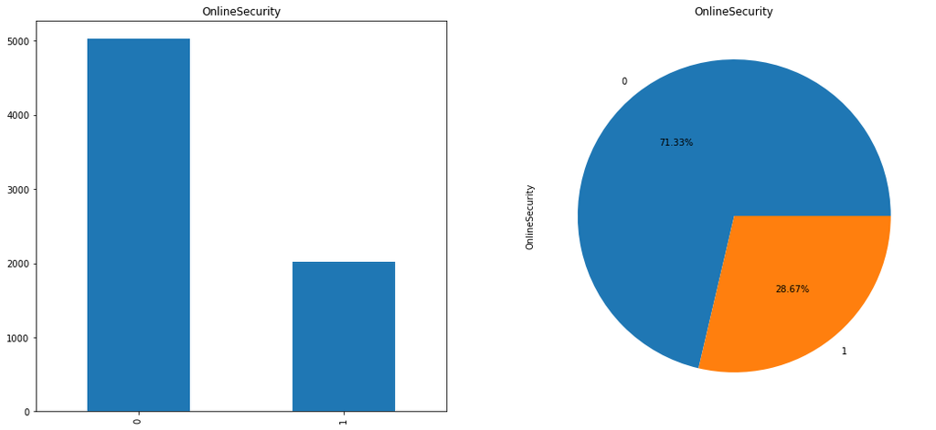

```python
plt.figure(figsize=(18,8))
plt.subplot(1,2,1)
plt.title('OnlineSecurity')
df.OnlineSecurity.value_counts().plot.bar();

plt.subplot(1,2,2)
plt.title('OnlineSecurity')
df.OnlineSecurity.value_counts().plot.pie(autopct='%1.2f%%');
```

the distribution 0 (no online security) is 71.33% and 1 (with online security) distribution is 28.67%.

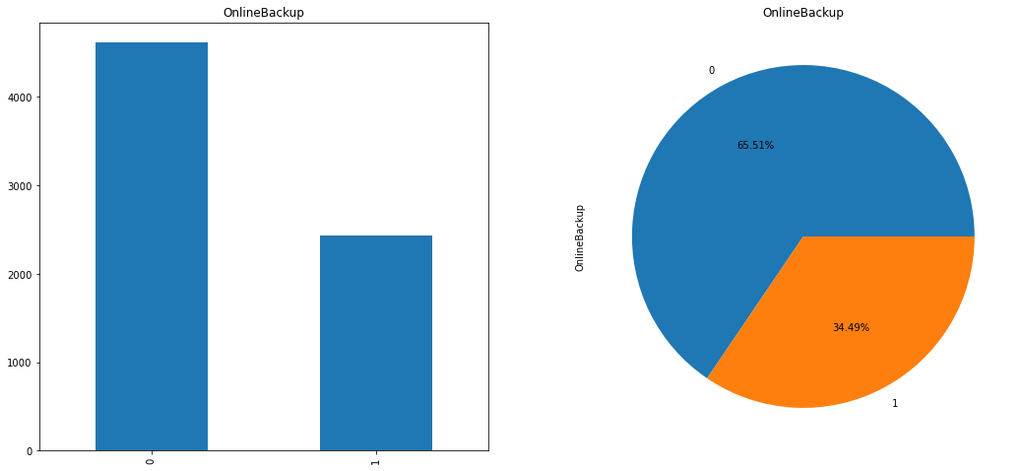

```python
plt.figure(figsize=(18,8))
plt.subplot(1,2,1)
plt.title('OnlineBackup')
df.OnlineBackup.value_counts().plot.bar();

plt.subplot(1,2,2)
plt.title('OnlineBackup')
df.OnlineBackup.value_counts().plot.pie(autopct='%1.2f%%');
```

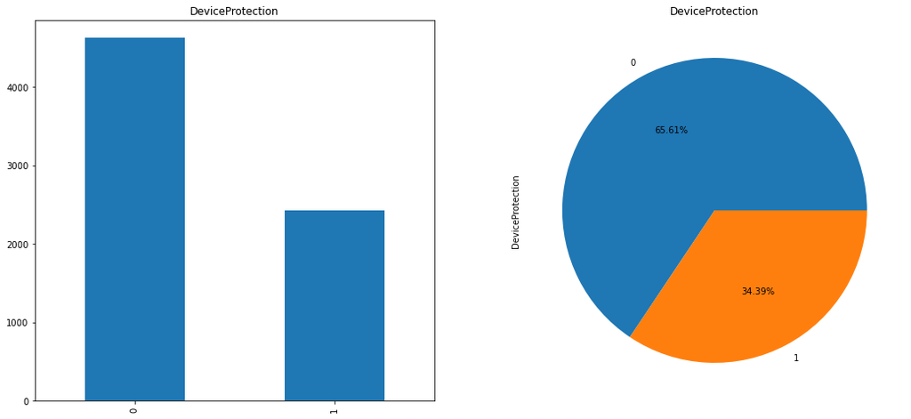

```python
plt.figure(figsize=(18,8))
plt.subplot(1,2,1)
plt.title('DeviceProtection')
df.DeviceProtection.value_counts().plot.bar();

plt.subplot(1,2,2)
plt.title('DeviceProtection')
df.DeviceProtection.value_counts().plot.pie(autopct='%1.2f%%');
```

the distribution 0 (no device protection/no internet service ) is 65.61% and 1 (with device protection) distribution is 34.39%.

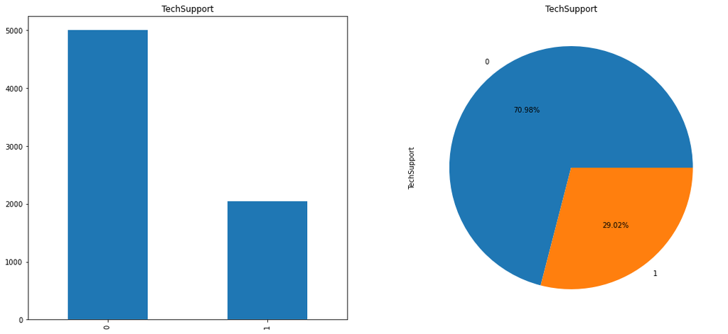

```python
plt.figure(figsize=(18,8))
plt.subplot(1,2,1)
plt.title('TechSupport')
df.TechSupport.value_counts().plot.bar();

plt.subplot(1,2,2)
plt.title('TechSupport')
df.TechSupport.value_counts().plot.pie(autopct='%1.2f%%');
```

the distributions 70.98% of '0' (no tech support/no internet service ) and 29.02% of '1' (with tech support).

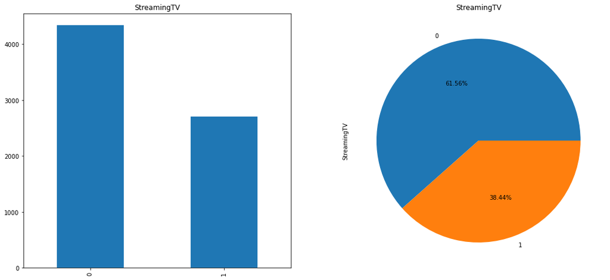

```python
plt.figure(figsize=(18,8))
plt.subplot(1,2,1)
plt.title('StreamingTV')
df.StreamingTV.value_counts().plot.bar();

plt.subplot(1,2,2)
plt.title('StreamingTV')
df.StreamingTV.value_counts().plot.pie(autopct='%1.2f%%');
```

the distribution 0 (no streaming tv/no internet service ) is 61.56% and 1 (streaming tv) distribution is 38.44%.

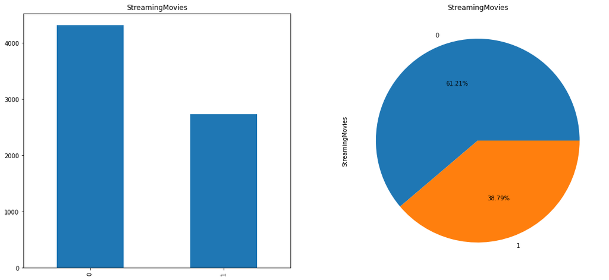

```python
plt.figure(figsize=(18,8))
plt.subplot(1,2,1)
plt.title('StreamingMovies')
df.StreamingMovies.value_counts().plot.bar();

plt.subplot(1,2,2)
plt.title('StreamingMovies')
df.StreamingMovies.value_counts().plot.pie(autopct='%1.2f%%');
```

the distribution 0 (no streaming movies/no internet service ) is 61.21% and 1 (streaming movies) distribution is 38.79%.

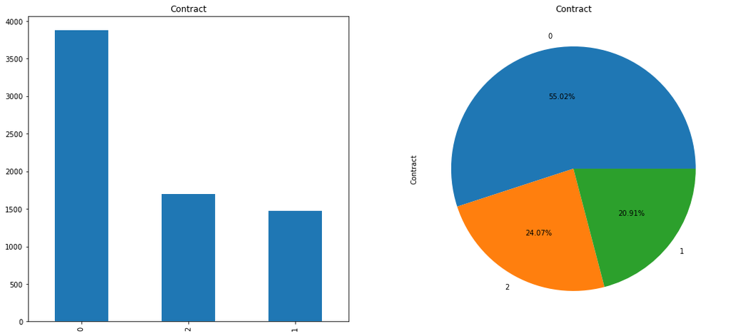

```python
plt.figure(figsize=(18,8))
plt.subplot(1,2,1)
plt.title('Contract')
df.Contract.value_counts().plot.bar();

plt.subplot(1,2,2)
plt.title('Contract')
df.Contract.value_counts().plot.pie(autopct='%1.2f%%');
```

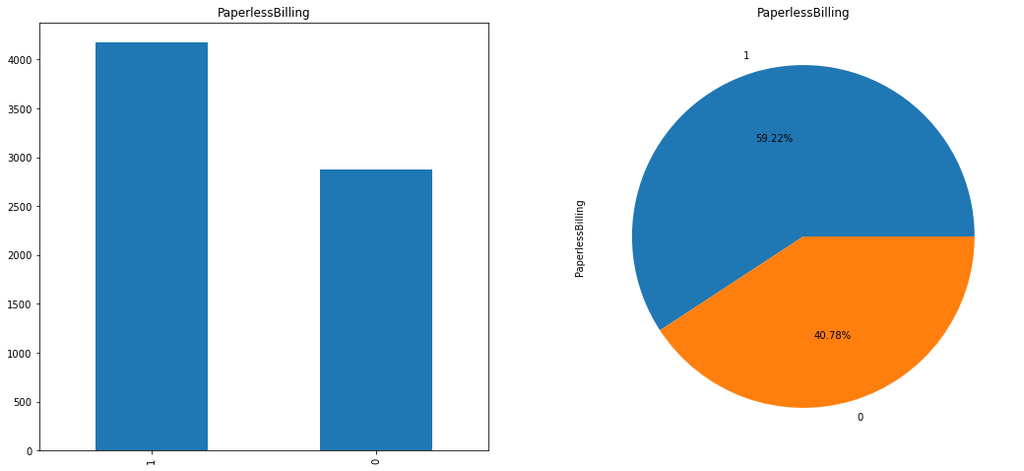

```python
plt.figure(figsize=(18,8))
plt.subplot(1,2,1)
plt.title('PaperlessBilling')
df.PaperlessBilling.value_counts().plot.bar();

plt.subplot(1,2,2)
plt.title('PaperlessBilling')
df.PaperlessBilling.value_counts().plot.pie(autopct='%1.2f%%');
```

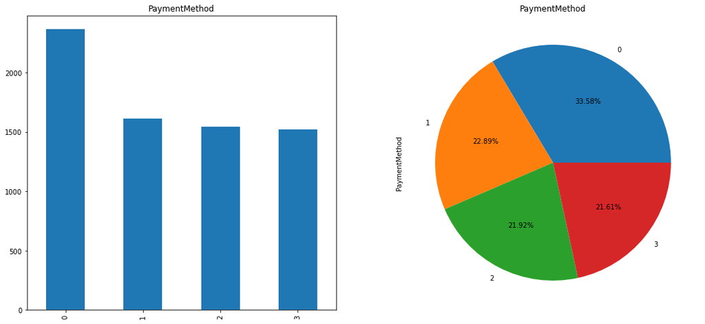

```python
plt.figure(figsize=(18,8))
plt.subplot(1,2,1)
plt.title('PaymentMethod')
df.PaymentMethod.value_counts().plot.bar();

plt.subplot(1,2,2)
plt.title('PaymentMethod')
df.PaymentMethod.value_counts().plot.pie(autopct='%1.2f%%');
```

the distribution for 'PaymentMethod' are 1. Electronic check -> 0 (33.58%) 2. Mailed check -> 1 (22.89%) 3. Bank transfer (automatic) -> 2 (21.92%) 4. Credit card (automatic) -> 3 (21.61%)

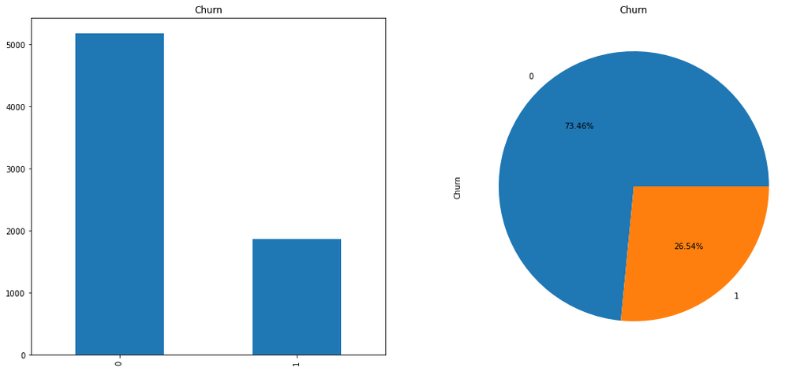

```python
# Distribution of target variable
plt.figure(figsize=(18,8))
plt.subplot(1,2,1)
plt.title('Churn')
df.Churn.value_counts().plot.bar();

plt.subplot(1,2,2)
plt.title('Churn')
df.Churn.value_counts().plot.pie(autopct='%1.2f%%');
```

The distribution are 0 (no churn ) is 73.46% and 1 (churn) distribution is 26.54%. Target variable distribution is not uniform. Most of the customers do not churn its only about 1/4th of the customer churned from the above dataset.

```
The number of outliers in 'MonthlyCharges' are 0
```

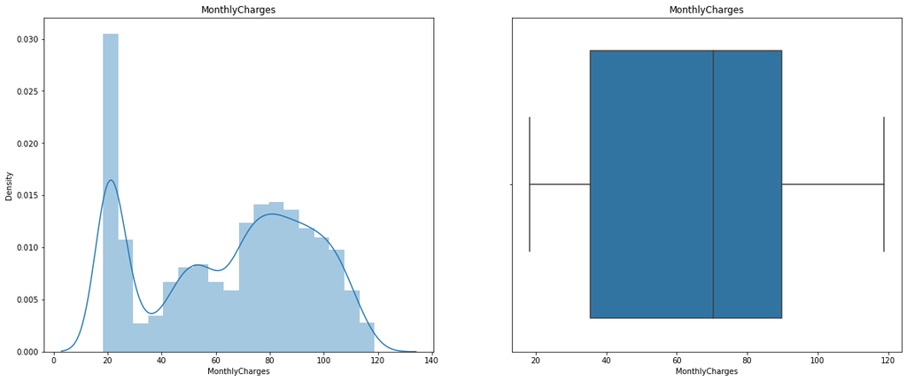

```python
plt.figure(figsize=(20,8))
plt.subplot(1,2,1)
plt.title('MonthlyCharges')
sns.distplot(df['MonthlyCharges']);

plt.subplot(1,2,2)
plt.title('MonthlyCharges')
sns.boxplot(df['MonthlyCharges']);

q25 = np.percentile(df['MonthlyCharges'],25)
q75 = np.percentile(df['MonthlyCharges'],75)
IQR = q75-q25
whisker = 1.5*IQR
upper_whisker = q75+whisker
lower_whisker = q25-whisker
outlier = [i for i in df['MonthlyCharges'] if i>upper_whisker or i<lower_whisker]
print(f'''The number of outliers in 'MonthlyCharges' are {len(outlier)}''')
```

Distribution is found not normal.And there are no outliers.

```
The number of outliers in 'TotalCharges' are 0
```

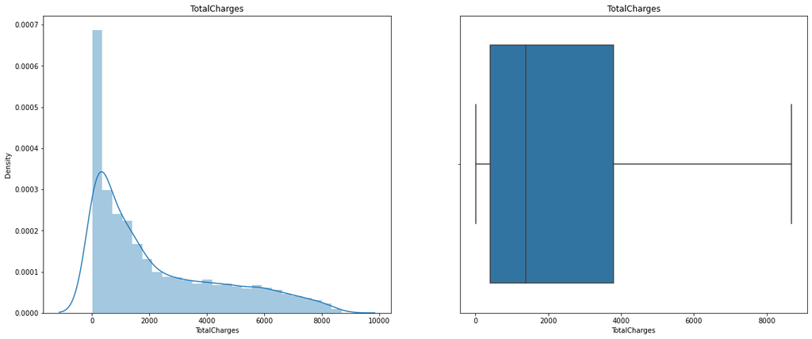

```python
plt.figure(figsize=(20,8))
plt.subplot(1,2,1)
plt.title('TotalCharges')
sns.distplot(df['TotalCharges']);

plt.subplot(1,2,2)
plt.title('TotalCharges')
sns.boxplot(df['TotalCharges']);

q25 = np.percentile(df['TotalCharges'],25)
q75 = np.percentile(df['TotalCharges'],75)
IQR = q75-q25
whisker = 1.5*IQR
upper_whisker = q75+whisker
lower_whisker = q25-whisker
outlier = [i for i in df['TotalCharges'] if i>upper_whisker or i<lower_whisker]
print(f'''The number of outliers in 'TotalCharges' are {len(outlier)}''')
```

Distribution is found not normal with skewness towards right. And there are no outliers.

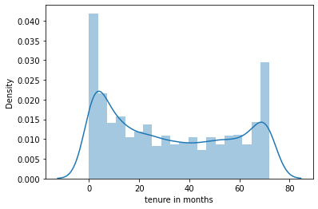

```python
sns.distplot(df['tenure'],axlabel='tenure in months',bins=20);
```

# Let us check the distribution of each categorical variable with respect to target variable

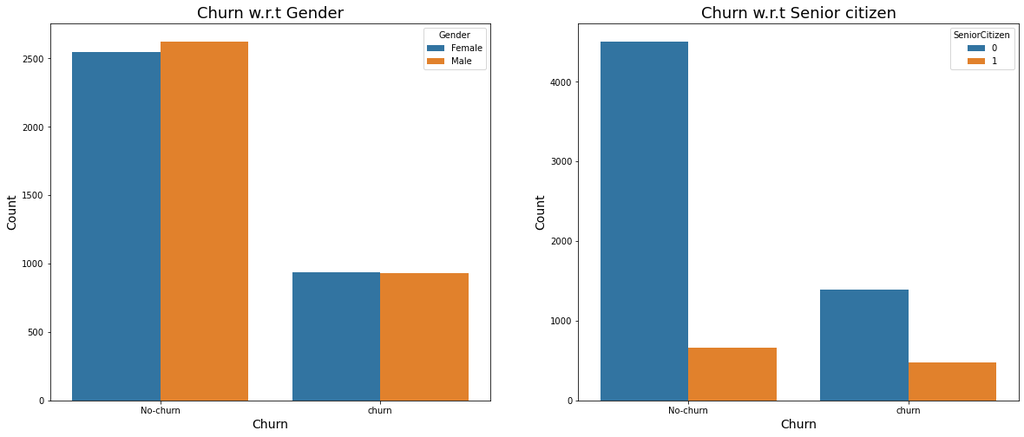

```python
plt.figure(figsize=(20,8))
plt.subplot(1,2,1)
fig=sns.countplot(x='Churn',hue='gender',data=df);
fig.set(xticklabels=['No-churn','churn']);
fig.set_title('Churn w.r.t Gender',fontsize=18);
fig.set_xlabel('Churn',fontsize=14);
fig.set_ylabel('Count',fontsize=14);
fig.legend(title='Gender',labels=['Female','Male'])

plt.subplot(1,2,2);
fig=sns.countplot(x='Churn',hue='SeniorCitizen',data=df);
fig.set(xticklabels=['No-churn','churn']);
fig.set_title('Churn w.r.t Senior citizen',fontsize=18);
fig.set_xlabel('Churn',fontsize=14);
fig.set_ylabel('Count',fontsize=14);
```

1.No churn count is more than churn for both 'Male' and 'Female'. Churn count is almost equal for both 'Male' and 'Female'. 2.No churn count for 'seniorcitizen' is comparitevly more than churn count.

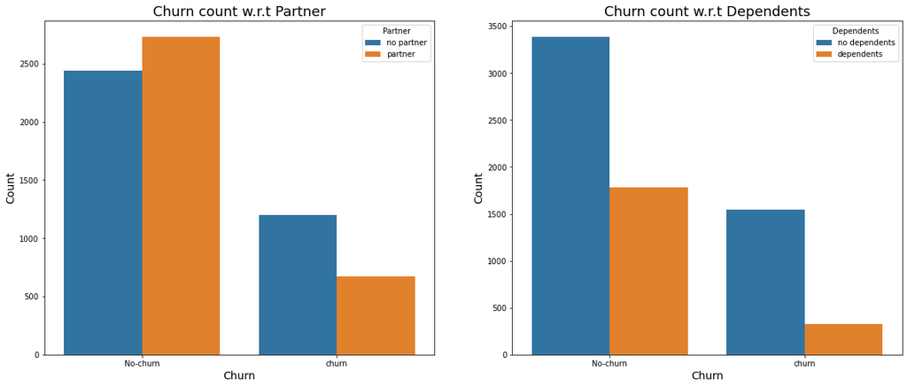

```python
plt.figure(figsize=(20,8))
plt.subplot(1,2,1)
fig=sns.countplot(x='Churn',hue='Partner',data=df);
fig.set(xticklabels=['No-churn','churn']);
fig.set_title('Churn count w.r.t Partner',fontsize=18);
fig.set_xlabel('Churn',fontsize=14)
fig.set_ylabel('Count',fontsize=14)
fig.legend(title='Partner',labels=['no partner','partner']);

plt.subplot(1,2,2)
fig=sns.countplot(x='Churn',hue='Dependents',data=df);
fig.set(xticklabels=['No-churn','churn']);
fig.set_title('Churn count w.r.t Dependents',fontsize=18);
fig.set_xlabel('Churn',fontsize=14)
fig.set_ylabel('Count',fontsize=14)
fig.legend(title='Dependents',labels=['no dependents','dependents']);
```

1.No churn count for partner is higher than churn count. Churn rate is higher for customers with no partner than for customers with partner. 2.No churn count for non dependent is superior compared to all. Churn count is lowest for customers with dependents.

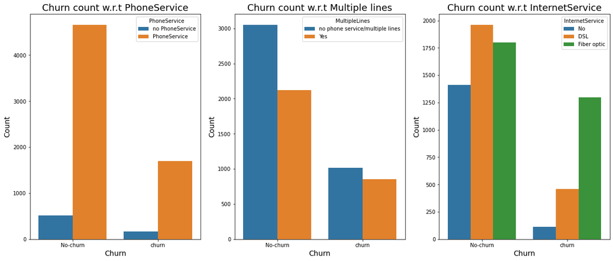

```python
plt.figure(figsize=(20,8))
plt.subplot(1,3,1)
fig=sns.countplot(x='Churn',hue='PhoneService',data=df);
fig.set(xticklabels=['No-churn','churn']);
fig.set_title('Churn count w.r.t PhoneService',fontsize=18);
fig.set_xlabel('Churn',fontsize=14)
fig.set_ylabel('Count',fontsize=14)
fig.legend(title='PhoneService',labels=['no PhoneService','PhoneService']);

plt.subplot(1,3,2)
fig=sns.countplot(x='Churn',hue='MultipleLines',data=df);
fig.set(xticklabels=['No-churn','churn']);
fig.set_title('Churn count w.r.t Multiple lines',fontsize=18);
fig.set_xlabel('Churn',fontsize=14)
fig.set_ylabel('Count',fontsize=14)
fig.legend(title='MultipleLines',labels=['no phone service/multiple lines','Yes']);

plt.subplot(1,3,3)
fig=sns.countplot(x='Churn',hue='InternetService',data=df);
fig.set(xticklabels=['No-churn','churn']);
fig.set_title('Churn count w.r.t InternetService',fontsize=18);
fig.set_xlabel('Churn',fontsize=14)
fig.set_ylabel('Count',fontsize=14)
fig.legend(title='InternetService',labels=['No','DSL','Fiber optic']);
```

1. No churn and churn counts are higher for customers with 'phone service' in comparision with customers without 'phoneservice'
2. churn is lowest for customers who have taken multiple lines.
3. churn is highest for customers who have opted for 'Fiber optic' followed by 'DSL' and no internet service provider.

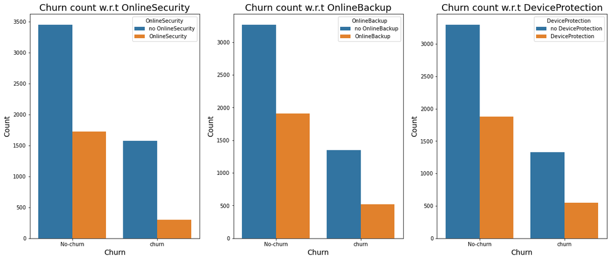

```python
plt.figure(figsize=(20,8))
plt.subplot(1,3,1)
fig=sns.countplot(x='Churn',hue='OnlineSecurity',data=df);
fig.set(xticklabels=['No-churn','churn']);
fig.set_title('Churn count w.r.t OnlineSecurity',fontsize=18);
fig.set_xlabel('Churn',fontsize=14)
fig.set_ylabel('Count',fontsize=14)
fig.legend(title='OnlineSecurity',labels=['no OnlineSecurity','OnlineSecurity']);

plt.subplot(1,3,2)
fig=sns.countplot(x='Churn',hue='OnlineBackup',data=df);
fig.set(xticklabels=['No-churn','churn']);
fig.set_title('Churn count w.r.t OnlineBackup',fontsize=18);
fig.set_xlabel('Churn',fontsize=14)
fig.set_ylabel('Count',fontsize=14)
fig.legend(title='OnlineBackup',labels=['no OnlineBackup','OnlineBackup']);

plt.subplot(1,3,3)
fig=sns.countplot(x='Churn',hue='DeviceProtection',data=df);
fig.set(xticklabels=['No-churn','churn']);
fig.set_title('Churn count w.r.t DeviceProtection',fontsize=18);
fig.set_xlabel('Churn',fontsize=14)
fig.set_ylabel('Count',fontsize=14)
fig.legend(title='DeviceProtection',labels=['no DeviceProtection','DeviceProtection']);
```

Churn is more for customers with no online security, no online backup and no device protection.

1. Churn is more for customers with noTechSupport,no StreamingTv and noStreamingMovies.

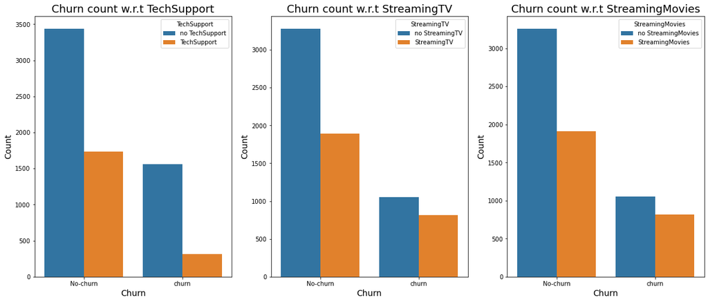

```python
plt.figure(figsize=(20,8))
plt.subplot(1,3,1)
fig=sns.countplot(x='Churn',hue='TechSupport',data=df);
fig.set(xticklabels=['No-churn','churn']);
fig.set_title('Churn count w.r.t TechSupport',fontsize=18);
fig.set_xlabel('Churn',fontsize=14)
fig.set_ylabel('Count',fontsize=14)
fig.legend(title='TechSupport',labels=['no TechSupport','TechSupport']);

plt.subplot(1,3,2)
fig=sns.countplot(x='Churn',hue='StreamingTV',data=df);
fig.set(xticklabels=['No-churn','churn']);
fig.set_title('Churn count w.r.t StreamingTV',fontsize=18);
fig.set_xlabel('Churn',fontsize=14)
fig.set_ylabel('Count',fontsize=14)
fig.legend(title='StreamingTV',labels=['no StreamingTV','StreamingTV']);

plt.subplot(1,3,3)
fig=sns.countplot(x='Churn',hue='StreamingMovies',data=df);
fig.set(xticklabels=['No-churn','churn']);
fig.set_title('Churn count w.r.t StreamingMovies',fontsize=18);
fig.set_xlabel('Churn',fontsize=14)
fig.set_ylabel('Count',fontsize=14)
fig.legend(title='StreamingMovies',labels=['no StreamingMovies','StreamingMovies']);
```

Churn is more for customers with no tech support,no streaming Tv and no streaming Movies.

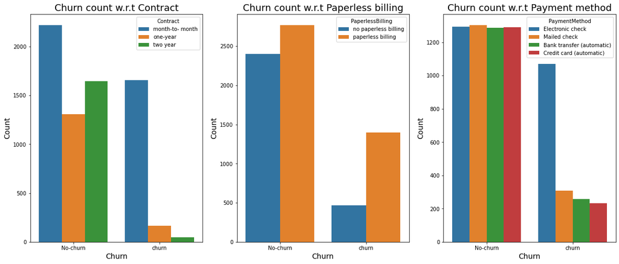

```python
plt.figure(figsize=(20,8))
plt.subplot(1,3,1)
fig=sns.countplot(x='Churn',hue='Contract',data=df);
fig.set(xticklabels=['No-churn','churn']);
fig.set_title('Churn count w.r.t Contract',fontsize=18);
fig.set_xlabel('Churn',fontsize=14)
fig.set_ylabel('Count',fontsize=14)
fig.legend(title='Contract',labels=['month-to- month','one-year','two year']);

plt.subplot(1,3,2)
fig=sns.countplot(x='Churn',hue='PaperlessBilling',data=df);
fig.set(xticklabels=['No-churn','churn']);
fig.set_title('Churn count w.r.t Paperless billing',fontsize=18);
fig.set_xlabel('Churn',fontsize=14)
fig.set_ylabel('Count',fontsize=14)
fig.legend(title='PaperlessBilling',labels=['no paperless billing','paperless billing']);

plt.subplot(1,3,3)
fig=sns.countplot(x='Churn',hue='PaymentMethod',data=df);
fig.set(xticklabels=['No-churn','churn']);
fig.set_title('Churn count w.r.t Payment method',fontsize=18);
fig.set_xlabel('Churn',fontsize=14)
fig.set_ylabel('Count',fontsize=14)
fig.legend(title='PaymentMethod',labels=['Electronic check','Mailed check','Bank transfer (automatic)','Credit card (automatic)']);
```

1.As for as contract is concerned churn is more of customers with month-to-month contract followed by One year and two year. 2.For paperless billing churn is more for customers with paperless billing. 3.churn is more for customers who opt for payment method by Electronic check followed by Mailed check, Bank transfer (automatic) and customers who opt for Credit card at last.

# Multivariate analysis

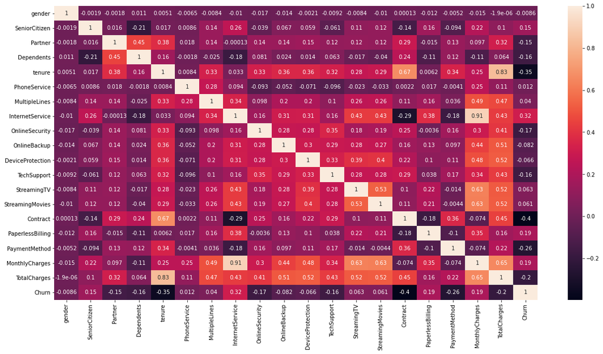

```python
plt.figure(figsize=(20,10))
sns.heatmap(df.corr(),annot=True);
```

```python
# corelation of the dependent variable over other independent attributes.
df.corr()['Churn'].sort_values(ascending = False)
```

```
Churn               1.000000
InternetService     0.316846
MonthlyCharges      0.193356
PaperlessBilling    0.191825
SeniorCitizen       0.150889
StreamingTV         0.063228
StreamingMovies     0.061382
MultipleLines       0.040102
PhoneService        0.011942
gender             -0.008612
DeviceProtection   -0.066160
OnlineBackup       -0.082255
Partner            -0.150448
Dependents         -0.164221
TechSupport        -0.164674
OnlineSecurity     -0.171226
TotalCharges       -0.199037
PaymentMethod      -0.262818
tenure             -0.352229
Contract           -0.396713
Name: Churn, dtype: float64
```

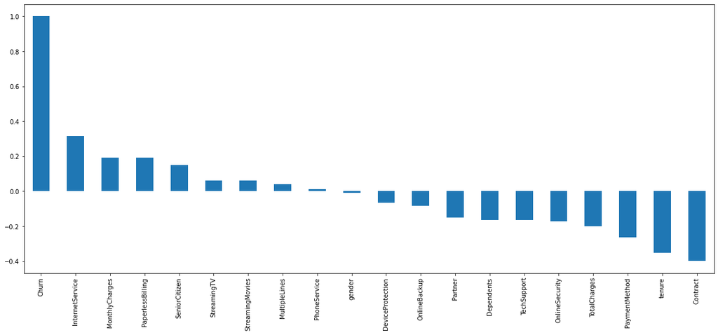

```python
plt.figure(figsize=(20,8))
df.corr()['Churn'].sort_values(ascending = False).plot(kind='bar');
```

# 4. Data pre-processing

# Segregate predictors vs target attributes

```python
X = df.drop('Churn',axis=1) # Predictor variable
y = df['Churn']             # Targer variable
```

# Check for target balancing and fix it if found imbalanced.

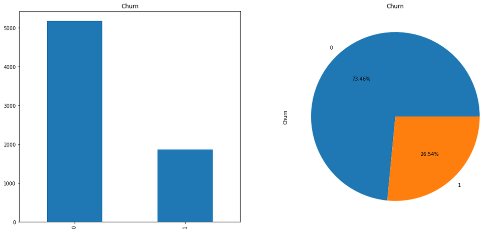

```python
plt.figure(figsize=(18,8))
plt.subplot(1,2,1)
plt.title('Churn')
df.Churn.value_counts().plot.bar();

plt.subplot(1,2,2)
plt.title('Churn')
df.Churn.value_counts().plot.pie(autopct='%1.2f%%');
```

Target variable distribution is not uniform.

# will proceed with the balancing of target variable

# Undersampling (Near Mess)

```python
from collections import Counter
from imblearn.under_sampling import NearMiss
ns = NearMiss(0.8)
X_s,y_s = ns.fit_sample(X,y)

print('Original target variable dataset shape:', Counter(y))
print('target distribution after balancing:', Counter(y_s))
```

```
Original target variable dataset shape: Counter({0: 5174, 1: 1869})
target distribution after balancing: Counter({0: 2336, 1: 1869})
```

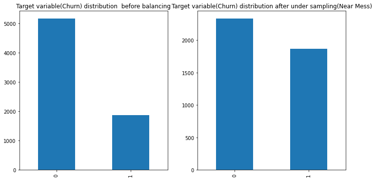

```python
plt.figure(figsize=(12,6))
plt.subplot(1,2,1)
y.value_counts().plot(kind='bar');
plt.title('Target variable(Churn) distribution  before balancing');

plt.subplot(1,2,2)
y_s.value_counts().plot(kind='bar');
plt.title('Target variable(Churn) distribution after under sampling(Near Mess)');
```

Undersampling leads to loss of values. It is highly recomend for large dataset. Let us try with oversampling.

# Oversampling (SMOTE)

```python
from collections import Counter
from imblearn.over_sampling import SMOTE

smote = SMOTE()

# fit target and predictor variable
X_sm , y_sm = smote.fit_sample(X, y)

print('Origianl dataset shape:',Counter(y))
print('Resampple dataset shape:',Counter(y_sm))
```

```
Origianl dataset shape: Counter({0: 5174, 1: 1869})
Resampple dataset shape: Counter({0: 5174, 1: 5174})
```

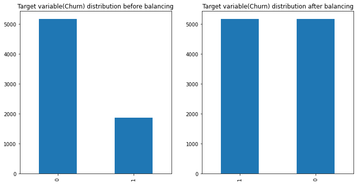

```python
plt.figure(figsize=(12,6))
plt.subplot(1,2,1)
y.value_counts().plot(kind='bar');
plt.title('Target variable(Churn) distribution before balancing');

plt.subplot(1,2,2)
y_sm.value_counts().plot(kind='bar');
plt.title('Target variable(Churn) distribution after balancing');
```

The distribution of target variable is found uniform. Will consider this sampling method.

# Perform train-test split.

```python
from sklearn.model_selection import train_test_split
X_train,X_test,y_train,y_test = train_test_split(X_sm,y_sm,train_size=0.8,random_state=27)
```

Will consider train and test split 80:20

# Checking train and test data

```python
# count of the target variable(after balancing)
y_sm.value_counts()
```

```
1    5174
0    5174
Name: Churn, dtype: int64
```

```python
# Since, 80% of the target variable distribution is considered for train size
y_train.value_counts()
```

```
1    4152
0    4126
Name: Churn, dtype: int64
```

```python
#20% of the target variable distribution is considered for test size
y_test.value_counts()
```

```
0    1048
1    1022
Name: Churn, dtype: int64
```

# 5. Model training, testing and tuning

# Train and test all ensemble models using different classifiers.

```python
# importing Libraries
from sklearn.linear_model import LogisticRegression
from sklearn.neighbors import KNeighborsClassifier
from sklearn.svm import SVC
from sklearn.tree import DecisionTreeClassifier
from sklearn.ensemble import RandomForestClassifier
from sklearn.ensemble import BaggingClassifier
from sklearn.ensemble import AdaBoostClassifier
from sklearn.ensemble import GradientBoostingClassifier
from sklearn.metrics import accuracy_score, confusion_matrix, classification_report
```

# Logistic Regression

```python
LR = LogisticRegression(random_state=27)
LR = LR.fit(X_train,y_train)
y_pred = LR.predict(X_test)
LR_ac_tr = LR.score(X_train, y_train)
LR_ac_te = LR.score(X_test, y_test)
LR_mac   = accuracy_score(y_test,y_pred)

print('Accuracy for Training data:',LR_ac_tr)
print('Accuracy for Test data:',LR_ac_te)
print(confusion_matrix(y_test,y_pred))
print('Model Accuracy:',LR_mac )
print(classification_report(y_test,y_pred))
resultsDf = pd.DataFrame({'Model':['Logistic Regression'], 'Model accuracy': LR_mac,'Training accuracy':LR_ac_tr,'Testing accuracy': LR_ac_te})
resultsDf = resultsDf[['Model', 'Model accuracy','Training accuracy','Testing accuracy']]
resultsDf
```

```
Accuracy for Training data: 0.8091326407344769
Accuracy for Test data: 0.8
[[802 246]
 [168 854]]
Model Accuracy: 0.8
              precision    recall  f1-score   support

           0       0.83      0.77      0.79      1048
           1       0.78      0.84      0.80      1022

    accuracy                           0.80      2070
   macro avg       0.80      0.80      0.80      2070
weighted avg       0.80      0.80      0.80      2070
```

|  | Model | Model accuracy | Training accuracy | Testing accuracy |
| --- | --- | --- | --- | --- |
| 0 | Logistic Regression | 0.8 | 0.809133 | 0.8 |

# KNN Classifier

```python
KNN = KNeighborsClassifier(n_neighbors=5)
KNN.fit(X_train,y_train)
y_pred = KNN.predict(X_test)
KNN_ac_tr = KNN.score(X_train, y_train)
KNN_ac_te = KNN.score(X_test, y_test)
KNN_mac   = accuracy_score(y_test,y_pred)
print('Accuracy for Training data:',KNN_ac_tr)
print('Accuracy for Test data:',KNN_ac_te)
print(confusion_matrix(y_test,y_pred))
print('Model Accuracy:',KNN_mac)
print(classification_report(y_test,y_pred))
tempResultsDf = pd.DataFrame({'Model':['KNN Classifier'], 'Model accuracy': [KNN_mac],'Training accuracy':KNN_ac_tr,'Testing accuracy': KNN_ac_te})
resultsDf = pd.concat([resultsDf, tempResultsDf])
resultsDf = resultsDf[['Model', 'Model accuracy','Training accuracy','Testing accuracy']]
resultsDf
```

```
Accuracy for Training data: 0.8347426914713699
Accuracy for Test data: 0.7574879227053141
[[718 330]
 [172 850]]
Model Accuracy: 0.7574879227053141
              precision    recall  f1-score   support

           0       0.81      0.69      0.74      1048
           1       0.72      0.83      0.77      1022

    accuracy                           0.76      2070
   macro avg       0.76      0.76      0.76      2070
weighted avg       0.76      0.76      0.76      2070
```

|  | Model | Model accuracy | Training accuracy | Testing accuracy |
| --- | --- | --- | --- | --- |
| 0 | Logistic Regression | 0.800000 | 0.809133 | 0.800000 |
| 0 | KNN Classifier | 0.757488 | 0.834743 | 0.757488 |

# Support Vector Machine

```python
SVM = SVC(random_state=27)
SVM.fit(X_train,y_train)
y_pred = SVM.predict(X_test)

SVM_ac_tr = SVM.score(X_train, y_train)
SVM_ac_te = SVM.score(X_test, y_test)
SVM_mac   = accuracy_score(y_test,y_pred)
print('Accuracy for Training data:',SVM_ac_tr)
print('Accuracy for Test data:',SVM_ac_te)
print(confusion_matrix(y_test,y_pred))
print('Model Accuracy:',SVM_mac)
print(classification_report(y_test,y_pred))
tempResultsDf = pd.DataFrame({'Model':['SVM Classifier'], 'Model accuracy':[SVM_mac],'Training accuracy':SVM_ac_tr,'Testing accuracy':SVM_ac_te})
resultsDf = pd.concat([resultsDf, tempResultsDf])
resultsDf = resultsDf[['Model', 'Model accuracy','Training accuracy','Testing accuracy']]
resultsDf
```

```
Accuracy for Training data: 0.660062817105581
Accuracy for Test data: 0.6584541062801932
[[744 304]
 [403 619]]
Model Accuracy: 0.6584541062801932
              precision    recall  f1-score   support

           0       0.65      0.71      0.68      1048
           1       0.67      0.61      0.64      1022

    accuracy                           0.66      2070
   macro avg       0.66      0.66      0.66      2070
weighted avg       0.66      0.66      0.66      2070
```

|  | Model | Model accuracy | Training accuracy | Testing accuracy |
| --- | --- | --- | --- | --- |
| 0 | Logistic Regression | 0.800000 | 0.809133 | 0.800000 |
| 0 | KNN Classifier | 0.757488 | 0.834743 | 0.757488 |
| 0 | SVM Classifier | 0.658454 | 0.660063 | 0.658454 |

# Decision Tree Classifier

```python
DT = DecisionTreeClassifier(random_state=27, max_depth=9)
DT = DT.fit(X_train,y_train)
y_pred = DT.predict(X_test)

DT_ac_tr = DT.score(X_train, y_train)
DT_ac_te = DT.score(X_test, y_test)
DT_mac   = accuracy_score(y_test,y_pred)
print('Accuracy for Training data:',DT_ac_tr)
print('Accuracy for Test data:',DT_ac_te)
print(confusion_matrix(y_test,y_pred))
print('Model Accuracy:',DT_mac)
print(classification_report(y_test,y_pred))
tempResultsDf = pd.DataFrame({'Model':['Decision tree Classifier'], 'Model accuracy': [DT_mac],'Training accuracy':DT_ac_tr,'Testing accuracy': DT_ac_te})
resultsDf = pd.concat([resultsDf, tempResultsDf])
resultsDf = resultsDf[['Model', 'Model accuracy','Training accuracy','Testing accuracy']]
resultsDf
```

```
Accuracy for Training data: 0.8610775549649674
Accuracy for Test data: 0.808695652173913
[[821 227]
 [169 853]]
Model Accuracy: 0.808695652173913
              precision    recall  f1-score   support

           0       0.83      0.78      0.81      1048
           1       0.79      0.83      0.81      1022

    accuracy                           0.81      2070
   macro avg       0.81      0.81      0.81      2070
weighted avg       0.81      0.81      0.81      2070
```

|  | Model | Model accuracy | Training accuracy | Testing accuracy |
| --- | --- | --- | --- | --- |
| 0 | Logistic Regression | 0.800000 | 0.809133 | 0.800000 |
| 0 | KNN Classifier | 0.757488 | 0.834743 | 0.757488 |
| 0 | SVM Classifier | 0.658454 | 0.660063 | 0.658454 |
| 0 | Decision tree Classifier | 0.808696 | 0.861078 | 0.808696 |

# Random Forest Classifier

```python
RF = RandomForestClassifier(random_state=27,n_estimators=50)
RF = RF.fit(X_train,y_train)
y_pred = RF.predict(X_test)

RF_ac_tr = RF.score(X_train, y_train)
RF_ac_te = RF.score(X_test, y_test)
RF_mac   = accuracy_score(y_test,y_pred)
print('Accuracy for Training data:',RF_ac_tr)
print('Accuracy for Test data:',RF_ac_te)
print(confusion_matrix(y_test,y_pred))
print('Model Accuracy:',RF_mac)
print(classification_report(y_test,y_pred))
tempResultsDf = pd.DataFrame({'Model':['Random forest Classifier'], 'Model accuracy': [RF_mac],'Training accuracy':RF_ac_tr,'Testing accuracy': RF_ac_te})
resultsDf = pd.concat([resultsDf, tempResultsDf])
resultsDf = resultsDf[['Model', 'Model accuracy','Training accuracy','Testing accuracy']]
resultsDf
```

```
Accuracy for Training data: 0.9984295723604736
Accuracy for Test data: 0.8434782608695652
[[867 181]
 [143 879]]
Model Accuracy: 0.8434782608695652
              precision    recall  f1-score   support

           0       0.86      0.83      0.84      1048
           1       0.83      0.86      0.84      1022

    accuracy                           0.84      2070
   macro avg       0.84      0.84      0.84      2070
weighted avg       0.84      0.84      0.84      2070
```

|  | Model | Model accuracy | Training accuracy | Testing accuracy |
| --- | --- | --- | --- | --- |
| 0 | Logistic Regression | 0.800000 | 0.809133 | 0.800000 |
| 0 | KNN Classifier | 0.757488 | 0.834743 | 0.757488 |
| 0 | SVM Classifier | 0.658454 | 0.660063 | 0.658454 |
| 0 | Decision tree Classifier | 0.808696 | 0.861078 | 0.808696 |
| 0 | Random forest Classifier | 0.843478 | 0.998430 | 0.843478 |

# Bagging Classifier

```python
BG = BaggingClassifier(random_state=27)
BG = BG.fit(X_train, y_train)
y_pred = BG.predict(X_test)

BG_ac_tr = BG.score(X_train, y_train)
BG_ac_te = BG.score(X_test, y_test)
BG_mac   = accuracy_score(y_test,y_pred)
print('Accuracy for Training data:',BG_ac_tr)
print('Accuracy for Test data:',BG_ac_te)
print(confusion_matrix(y_test,y_pred))
print('Model Accuracy:',BG_mac)
print(classification_report(y_test,y_pred))
tempResultsDf = pd.DataFrame({'Model':['Bagging Classifier'], 'Model accuracy': [BG_mac],'Training accuracy':BG_ac_tr,'Testing accuracy': BG_ac_te})
resultsDf = pd.concat([resultsDf, tempResultsDf])
resultsDf = resultsDf[['Model', 'Model accuracy','Training accuracy','Testing accuracy']]
resultsDf
```

```
Accuracy for Training data: 0.9857453491181445
Accuracy for Test data: 0.8241545893719807
[[872 176]
 [188 834]]
Model Accuracy: 0.8241545893719807
              precision    recall  f1-score   support

           0       0.82      0.83      0.83      1048
           1       0.83      0.82      0.82      1022

    accuracy                           0.82      2070
   macro avg       0.82      0.82      0.82      2070
weighted avg       0.82      0.82      0.82      2070
```

|  | Model | Model accuracy | Training accuracy | Testing accuracy |
| --- | --- | --- | --- | --- |
| 0 | Logistic Regression | 0.800000 | 0.809133 | 0.800000 |
| 0 | KNN Classifier | 0.757488 | 0.834743 | 0.757488 |
| 0 | SVM Classifier | 0.658454 | 0.660063 | 0.658454 |
| 0 | Decision tree Classifier | 0.808696 | 0.861078 | 0.808696 |
| 0 | Random forest Classifier | 0.843478 | 0.998430 | 0.843478 |
| 0 | Bagging Classifier | 0.824155 | 0.985745 | 0.824155 |

# ADA Boost Classifier

```python
AB = AdaBoostClassifier(random_state=27)
AB = AB.fit(X_train,y_train)
y_pred = AB.predict(X_test)

AB_ac_tr = AB.score(X_train, y_train)
AB_ac_te = AB.score(X_test, y_test)
AB_mac   = accuracy_score(y_test,y_pred)
print('Accuracy for Training data:',AB_ac_tr)
print('Accuracy for Test data:',AB_ac_te)
print(confusion_matrix(y_test,y_pred))
print('Model Accuracy:',AB_mac)
print(classification_report(y_test,y_pred))
tempResultsDf = pd.DataFrame({'Model':['ADA Boost Classifier'], 'Model accuracy': [AB_mac],'Training accuracy':AB_ac_tr,'Testing accuracy': AB_ac_te})
resultsDf = pd.concat([resultsDf, tempResultsDf])
resultsDf = resultsDf[['Model', 'Model accuracy','Training accuracy','Testing accuracy']]
resultsDf
```

```
Accuracy for Training data: 0.8227832809857454
Accuracy for Test data: 0.8120772946859903
[[796 252]
 [137 885]]
Model Accuracy: 0.8120772946859903
              precision    recall  f1-score   support

           0       0.85      0.76      0.80      1048
           1       0.78      0.87      0.82      1022

    accuracy                           0.81      2070
   macro avg       0.82      0.81      0.81      2070
weighted avg       0.82      0.81      0.81      2070
```

|  | Model | Model accuracy | Training accuracy | Testing accuracy |
| --- | --- | --- | --- | --- |
| 0 | Logistic Regression | 0.800000 | 0.809133 | 0.800000 |
| 0 | KNN Classifier | 0.757488 | 0.834743 | 0.757488 |
| 0 | SVM Classifier | 0.658454 | 0.660063 | 0.658454 |
| 0 | Decision tree Classifier | 0.808696 | 0.861078 | 0.808696 |
| 0 | Random forest Classifier | 0.843478 | 0.998430 | 0.843478 |
| 0 | Bagging Classifier | 0.824155 | 0.985745 | 0.824155 |
| 0 | ADA Boost Classifier | 0.812077 | 0.822783 | 0.812077 |

# GB Classifier

```python
GB = GradientBoostingClassifier(random_state=27)
GB = GB.fit(X_train, y_train)
y_pred = GB.predict(X_test)

GB_ac_tr = GB.score(X_train, y_train)
GB_ac_te = GB.score(X_test, y_test)
GB_mac   = accuracy_score(y_test,y_pred)
print('Accuracy for Training data:',GB_ac_tr)
print('Accuracy for Test data:',GB_ac_te)
print(confusion_matrix(y_test,y_pred))
print('Model Accuracy:',GB_mac)
print(classification_report(y_test,y_pred))
tempResultsDf = pd.DataFrame({'Model':['Gradient Boost Classifier'], 'Model accuracy': [GB_mac],'Training accuracy':GB_ac_tr,'Testing accuracy': GB_ac_te})
resultsDf = pd.concat([resultsDf, tempResultsDf])
resultsDf = resultsDf[['Model', 'Model accuracy','Training accuracy','Testing accuracy']]
resultsDf
```

```
Accuracy for Training data: 0.8459772892002899
Accuracy for Test data: 0.821256038647343
[[820 228]
 [142 880]]
Model Accuracy: 0.821256038647343
              precision    recall  f1-score   support

           0       0.85      0.78      0.82      1048
           1       0.79      0.86      0.83      1022

    accuracy                           0.82      2070
   macro avg       0.82      0.82      0.82      2070
weighted avg       0.82      0.82      0.82      2070
```

|  | Model | Model accuracy | Training accuracy | Testing accuracy |
| --- | --- | --- | --- | --- |
| 0 | Logistic Regression | 0.800000 | 0.809133 | 0.800000 |
| 0 | KNN Classifier | 0.757488 | 0.834743 | 0.757488 |
| 0 | SVM Classifier | 0.658454 | 0.660063 | 0.658454 |
| 0 | Decision tree Classifier | 0.808696 | 0.861078 | 0.808696 |
| 0 | Random forest Classifier | 0.843478 | 0.998430 | 0.843478 |
| 0 | Bagging Classifier | 0.824155 | 0.985745 | 0.824155 |
| 0 | ADA Boost Classifier | 0.812077 | 0.822783 | 0.812077 |
| 0 | Gradient Boost Classifier | 0.821256 | 0.845977 | 0.821256 |